# COVID-19

Istvan Nemeth

2020-04-25

# Introduction

The analyses to come, have many weaknesses. The weakness of data; case reporting policies change from country to country – lucky if not within country. The weakness of assumptions. 1) Transmission dynamics do not change over the course of epidemic (this obviously does not hold as governments in their way to stop it, make up new ideas every day and legislate on the other). 2) The underlying math model is simple. This is a plain density function of a normal distribution. Plus a scale parameter. You can not tweak things in easily, like changes in social distancing, season effect or whatever you may think it affects the spread of COVID-19. This is not going to be a sonnet; this is a troll song. But like every troll, it is effective and lazy. Moreover, I do not feel like chasing after government COVID-19 regulations and time it become effective, just as an entry level of building a non-troll subtle model. When you have kids in quarantine you will know why. You do have - OK, so you know.

Data used in these analyses is publicly available at ECDC site [here](https://opendata.ecdc.europa.eu/covid19/casedistribution/csv).

Actual content may change over time as global COVID-19 situation develops over time.

# Italy

- Cases to date: 192994
- Total cases estimated: 208783
- Date after cases/day is expeted to be less then 10: 2020-05-27

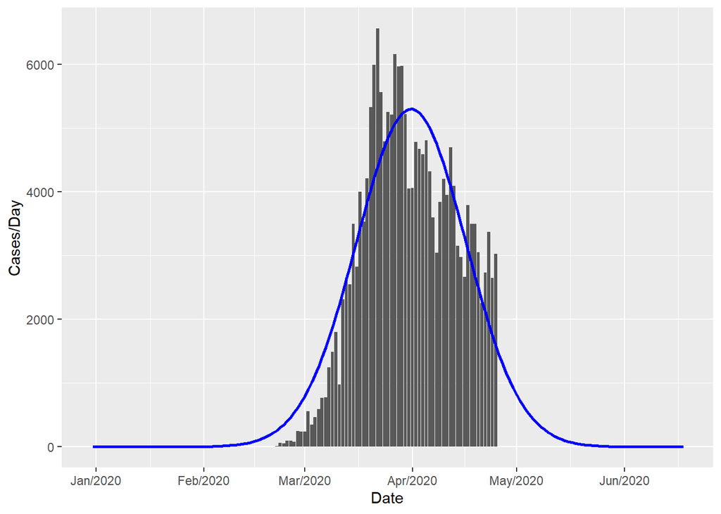

# Germany

- Cases to date: 152438
- Total cases estimated: 158156
- Date after cases/day is expeted to be less then 10: 2020-05-15

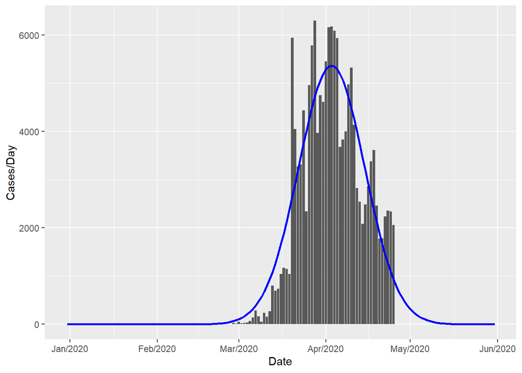

# UK

- Cases to date: 143464
- Total cases estimated: 184296
- Date after cases/day is expeted to be less then 10: 2020-06-01

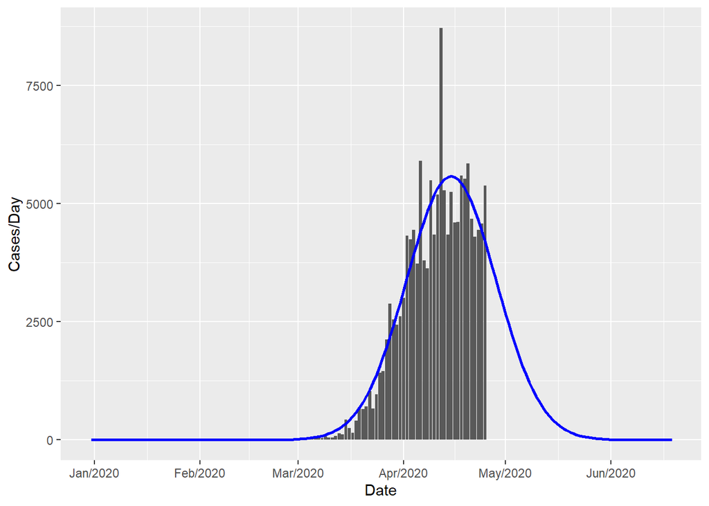

# Spain

- Cases to date: 219764
- Total cases estimated: 237656
- Date after cases/day is expeted to be less then 10: 2020-05-23

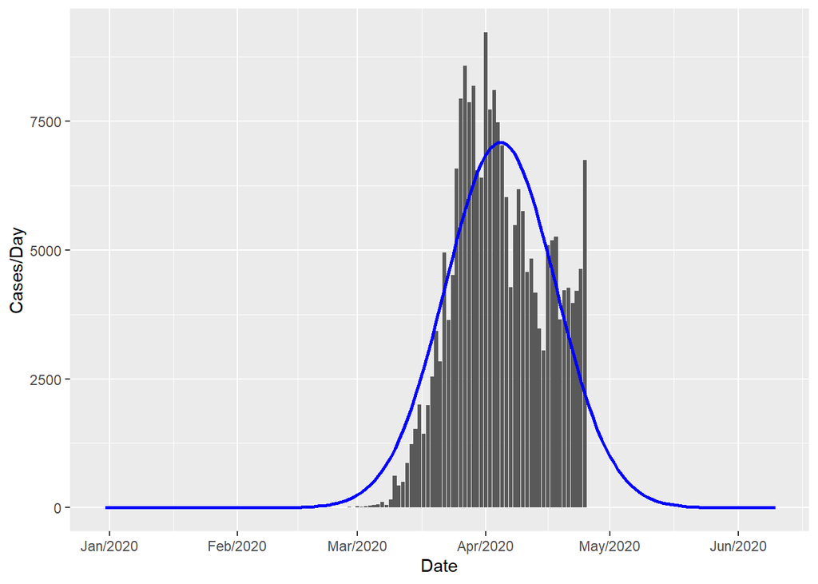

# USA

- Cases to date: 890524
- Total cases estimated: 1076199
- Date after cases/day is expeted to be less then 10: 2020-06-04

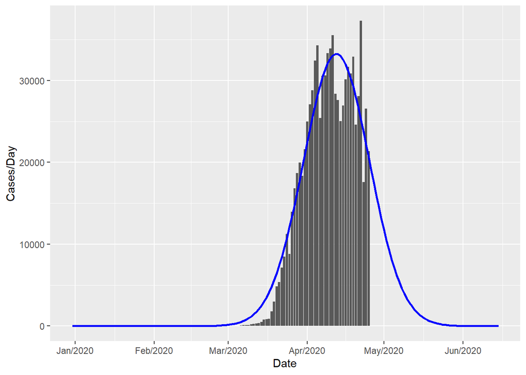